# PSC article analysis Q1 - NORWAY

# Analysis - Colon

```r
segment="colon"
```

## Filtering

Library size

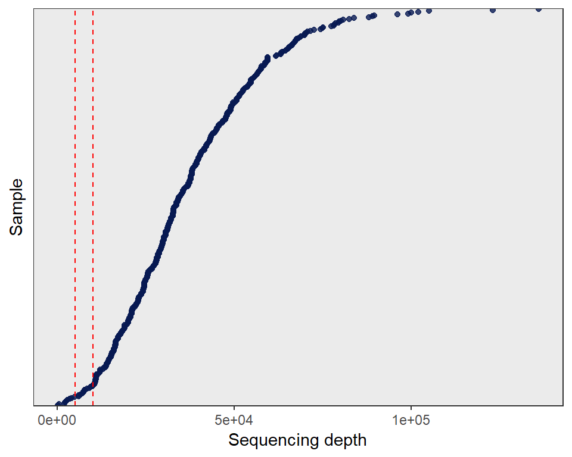

```r
read_counts(colon_asv_tab, line = c(5000,10000))
```

### Sequencing depth

```r
data_filt <- seq_depth_filtering(colon_asv_tab,
                                 colon_taxa_tab,
                                 colon_metadata,
                                 seq_depth_threshold = 10000)
```

```
## Removing 85 ASV(s)
```

```r
filt_colon_asv_tab <- data_filt[[1]]; alpha_colon_asv_tab <- filt_colon_asv_tab
filt_colon_taxa_tab <- data_filt[[2]]; alpha_colon_taxa_tab <- filt_colon_taxa_tab
filt_colon_metadata <- data_filt[[3]]; alpha_colon_metadata <- filt_colon_metadata

seq_step <- dim(filt_colon_asv_tab)[1]
```

Library size

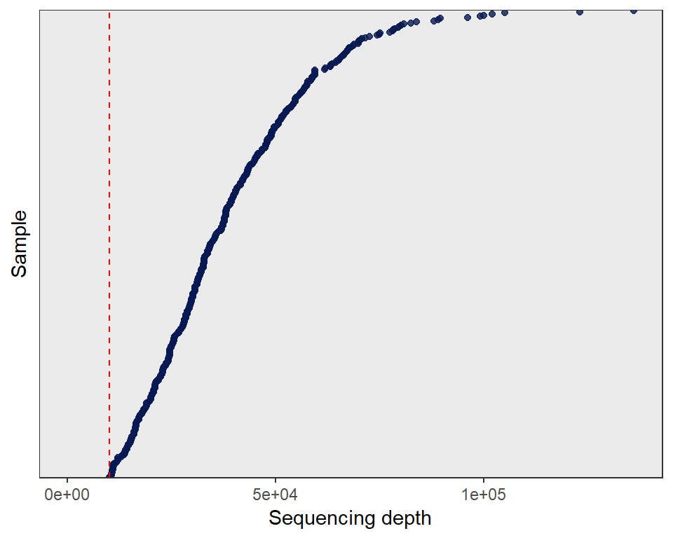

```r
read_counts(filt_colon_asv_tab,line = c(10000))
```

### NearZeroVar

```r
data_filt <- nearzerovar_filtering(filt_colon_asv_tab,
                                   filt_colon_taxa_tab,
                                   filt_colon_metadata)

filt_colon_asv_tab <- data_filt[[1]]
filt_colon_taxa_tab <- data_filt[[2]]
nearzero_step <- dim(filt_colon_asv_tab)[1]
```

Library size

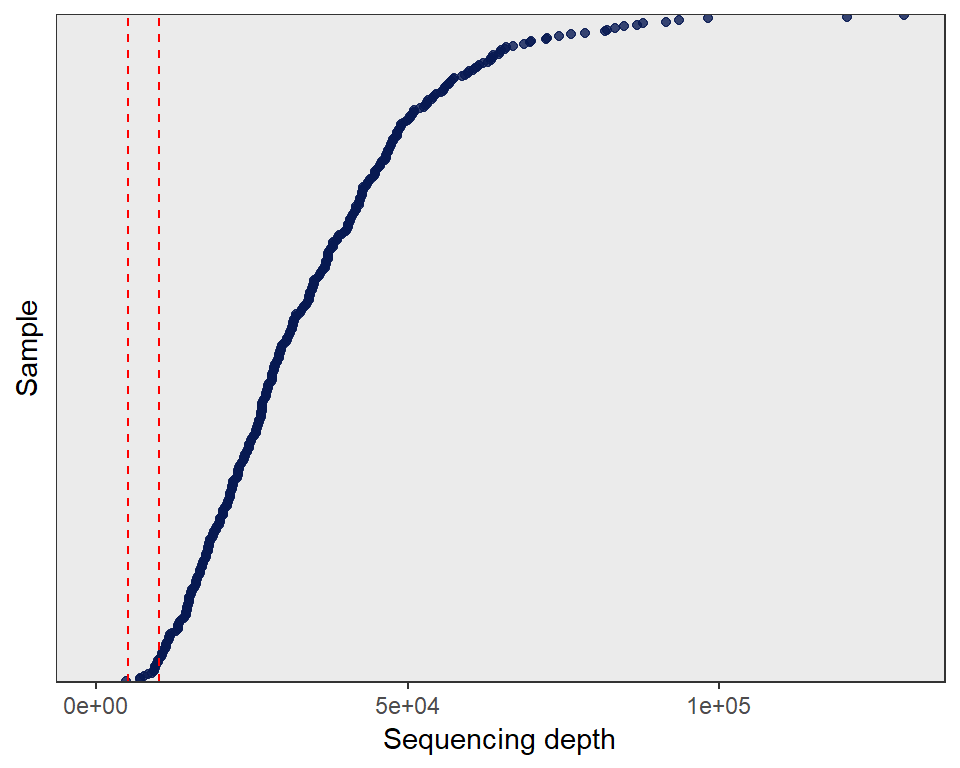

```r
read_counts(filt_colon_asv_tab,line = c(5000,10000))
```

Check zero depth

```r
data_filt <- check_zero_depth(filt_colon_asv_tab,
                              filt_colon_taxa_tab,
                              filt_colon_metadata)

filt_colon_asv_tab <- data_filt[[1]];
filt_colon_taxa_tab <- data_filt[[2]];
filt_colon_metadata <- data_filt[[3]];
```

Library size

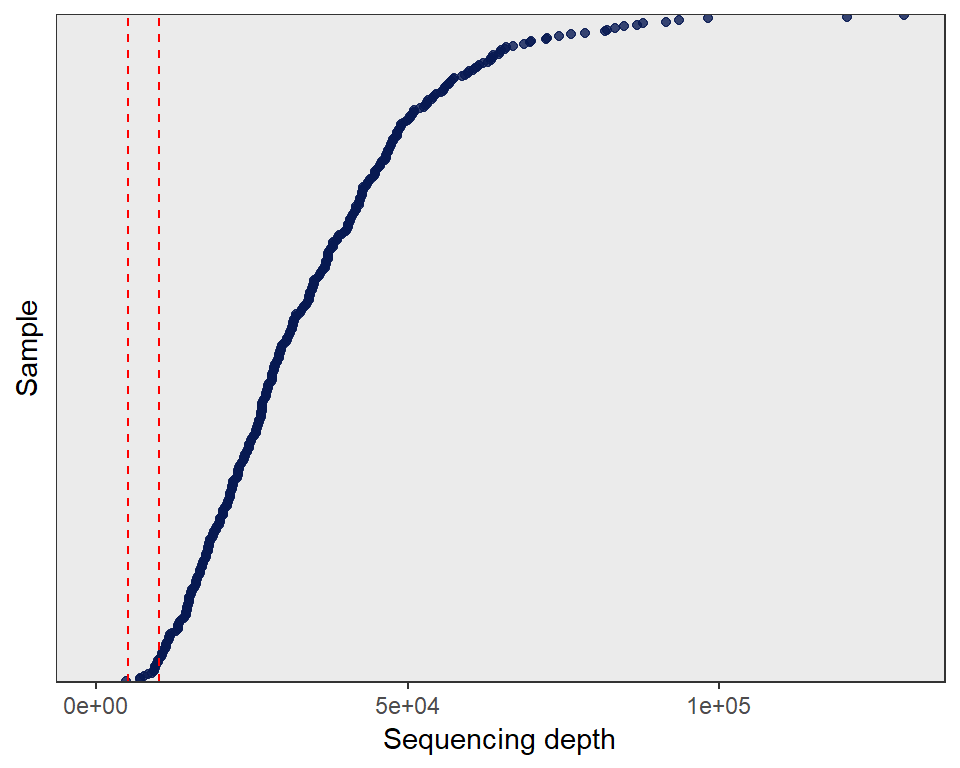

```r
read_counts(filt_colon_asv_tab,line = c(5000,10000))
```

### Final Counts

```r
final_counts_filtering(colon_asv_tab,
                       filt_colon_asv_tab,
                       filt_colon_metadata,
                       seq_step, 0, nearzero_step)
```

|  | V1 |
| --- | --- |
| Raw data: ASVs | 4639 |
| Raw data: Samples | 437 |
| Sequencing depth filt: ASVs | 4554 |
| Prevalence filt: ASVs | 0 |
| NearZeroVar filt: ASVs | 539 |
| Filt data: ASVs | 539 |
| Filt data: Samples | 415 |
| Filt data: Patients | 168 |
| Filt data: Patients.1 | 0 |
| Filtered samples | 22 |

[output cut: 7 more lines]

## Alpha diversity

```r
path = "../results/Q1_norway/alpha_diversity"
```

**Calculation**

```r
# Construct MPSE object
alpha_colon_metadata$Sample <- alpha_colon_metadata$SampleID
colon_mpse <- as.MPSE(construct_phyloseq(alpha_colon_asv_tab,
                                         alpha_colon_taxa_tab,
                                         alpha_colon_metadata))

colon_mpse %<>% mp_rrarefy(raresize = 10000,seed = 123)

# Calculate alpha diversity - rarefied counts
colon_mpse %<>% mp_cal_alpha(.abundance=RareAbundance, force=TRUE)
```

```r
alpha_data <- data.frame(SampleID=colon_mpse$Sample.x,
                         Observe=colon_mpse$Observe,
                         Shannon=colon_mpse$Shannon,
                         Simpson=colon_mpse$Simpson,
                         Pielou=colon_mpse$Pielou,
                         Group=colon_mpse$Group,
                         Country=colon_mpse$Country,
                         Patient=colon_mpse$Patient)

write.csv(alpha_data,file.path(path,paste0("alpha_indices_",segment,".csv")),
          row.names = FALSE)
```

**Plots**

### Custom plot

```r
alpha_data <- alpha_data %>%
  dplyr::select(-c("Simpson","Pielou")) %>%
  mutate(Richness=Observe)

p_B <- alpha_diversity_custom_2(alpha_data,
                                size = 1.5,
                                width = 0.3)
```

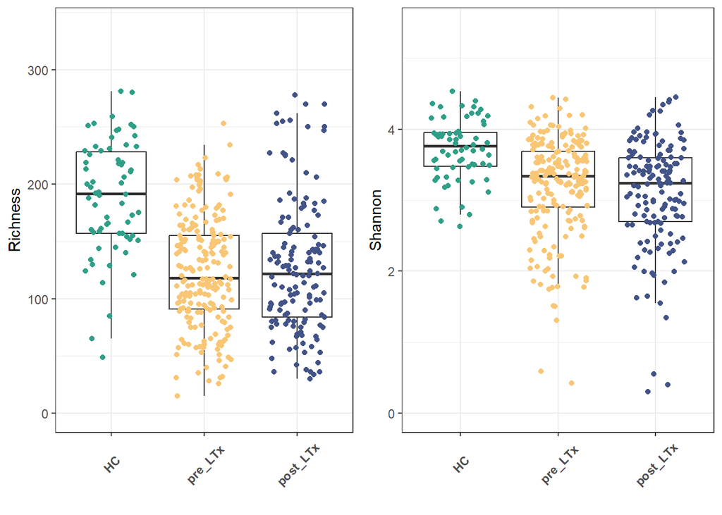

```r
# save the results
alpha_div_plots[[paste(segment,"Custom")]] <- p_B

p_B
```

### Linear Model

```r
path = "../results/Q1_norway/alpha_diversity"
alpha_data <- read.csv(file.path(path,paste0("alpha_indices_",segment,".csv")))
```

**Richness**

```r
results_model <- pairwise.lmer(
  formula = "Observe ~ Group + (1|Patient)",
  factors=alpha_data$Group,
  data=alpha_data)

# check interaction
if (!is.data.frame(results_model)){
  results_model_observe <- results_model[[1]]
  results_model_observe_detailed <- results_model[[2]]
} else {
  results_model_observe <- results_model
  results_model_observe_detailed <- NA
}

# save the results
pc_observed[[segment]] <- results_model_observe
```

```r
# see the results
knitr::kable(results_model_observe,digits = 3,
caption = "Raw results of linear model of richness estimation.")
```

Raw results of linear model of richness estimation.

|  | Estimate | Std..Error | df | t.value | Pr…t.. | p.adj | sig |
| --- | --- | --- | --- | --- | --- | --- | --- |
| healthy vs Grouppre_ltx | -62.898 | 9.494 | 116.518 | -6.625 | 0.000 | 0.000 | *** |
| pre_ltx vs Grouppost_ltx | 4.619 | 9.148 | 129.233 | 0.505 | 0.614 | 0.614 |  |
| healthy vs Grouppost_ltx | -58.354 | 11.528 | 87.226 | -5.062 | 0.000 | 0.000 | *** |

```r
# see the results
knitr::kable(results_model[[3]],digits = 3,
caption = "Group means")
```

Group means

|  | Estimate | Std. Error | df | t value | Pr(>\|t\|) |
| --- | --- | --- | --- | --- | --- |
| healthy | 185.593 | 8.821 | 89.016 | 21.039 | 0 |
| pre_ltx | 122.610 | 5.712 | 129.619 | 21.465 | 0 |
| healthy | 185.504 | 7.869 | 117.622 | 23.573 | 0 |

**Shannon**

```r
results_model <- pairwise.lmer(
  formula = "Shannon ~ Group + (1|Patient)",
  factors=alpha_data$Group,
  data=alpha_data)

# check interaction
if (!is.data.frame(results_model)){
  results_model_shannon <- results_model[[1]]
  results_model_shannon_detailed <- results_model[[2]]
} else {
  results_model_shannon <- results_model
  results_model_shannon_detailed <- NA
}

# save the results
pc_shannon[[segment]] <- as.data.frame(results_model_shannon)
```

```r
# see the results
knitr::kable(results_model_shannon,digits = 3,
caption = "Raw results of linear model of Shannon estimation.")
```

Raw results of linear model of Shannon estimation.

|  | Estimate | Std..Error | df | t.value | Pr…t.. | p.adj | sig |
| --- | --- | --- | --- | --- | --- | --- | --- |
| healthy vs Grouppre_ltx | -0.504 | 0.122 | 117.486 | -4.132 | 0.000 | 0.000 | *** |
| pre_ltx vs Grouppost_ltx | -0.090 | 0.125 | 129.047 | -0.719 | 0.473 | 0.473 |  |
| healthy vs Grouppost_ltx | -0.595 | 0.136 | 88.014 | -4.388 | 0.000 | 0.000 | *** |

```r
# see the results
knitr::kable(results_model[[3]],digits = 3,
caption = "Group means")
```

Group means

|  | Estimate | Std. Error | df | t value | Pr(>\|t\|) |
| --- | --- | --- | --- | --- | --- |
| healthy | 3.702 | 0.104 | 90.080 | 35.652 | 0 |
| pre_ltx | 3.197 | 0.078 | 129.527 | 40.945 | 0 |
| healthy | 3.701 | 0.101 | 118.959 | 36.557 | 0 |

**Simpson**

```r
results_model <- pairwise.lmer(
  formula = "Simpson ~ Group + (1|Patient)",
  factors=alpha_data$Group,
  data=alpha_data)

# check interaction
if (!is.data.frame(results_model)){
  results_model_simpson <- results_model[[1]]
  results_model_simpson_detailed <- results_model[[2]]
} else {
  results_model_simpson <- results_model
  results_model_simpson_detailed <- NA
}

# save the results
pc_simpson[[segment]] <- as.data.frame(results_model_simpson)
```

```r
# see the results
knitr::kable(results_model_simpson,digits = 3,
caption = "Raw results of linear model of Simpson estimation.")
```

Raw results of linear model of Simpson estimation.

|  | Estimate | Std..Error | df | t.value | Pr…t.. | p.adj | sig |
| --- | --- | --- | --- | --- | --- | --- | --- |
| healthy vs Grouppre_ltx | -0.039 | 0.017 | 117.614 | -2.257 | 0.026 | 0.039 | * |
| pre_ltx vs Grouppost_ltx | -0.020 | 0.020 | 128.829 | -1.000 | 0.319 | 0.319 |  |
| healthy vs Grouppost_ltx | -0.059 | 0.022 | 89.578 | -2.624 | 0.010 | 0.031 | * |

```r
# see the results
knitr::kable(results_model[[3]],digits = 3,
caption = "Group means")
```

Group means

|  | Estimate | Std. Error | df | t value | Pr(>\|t\|) |
| --- | --- | --- | --- | --- | --- |
| healthy | 0.936 | 0.017 | 91.967 | 54.406 | 0 |
| pre_ltx | 0.898 | 0.013 | 129.371 | 71.003 | 0 |
| healthy | 0.936 | 0.014 | 119.443 | 65.975 | 0 |

**Pielou**

```r
results_model <- pairwise.lmer(
  formula = "Pielou ~ Group + (1|Patient)",
  factors=alpha_data$Group,
  data=alpha_data)

# check interaction
if (!is.data.frame(results_model)){
  results_model_pielou <- results_model[[1]]
  results_model_pielou_detailed <- results_model[[2]]
} else {
  results_model_pielou <- results_model
  results_model_pielou_detailed <- NA
}

# save the results
pc_pielou[[segment]] <- as.data.frame(results_model_pielou)
```

```r
# see the results
knitr::kable(results_model_pielou,digits = 3,
caption = "Raw results of linear model of Pielou estimation.")
```

Raw results of linear model of Pielou estimation.

|  | Estimate | Std..Error | df | t.value | Pr…t.. | p.adj | sig |
| --- | --- | --- | --- | --- | --- | --- | --- |
| healthy vs Grouppre_ltx | -0.043 | 0.017 | 118.548 | -2.473 | 0.015 | 0.022 | * |
| pre_ltx vs Grouppost_ltx | -0.022 | 0.019 | 128.797 | -1.198 | 0.233 | 0.233 |  |
| healthy vs Grouppost_ltx | -0.066 | 0.021 | 89.175 | -3.175 | 0.002 | 0.006 | ** |

```r
# see the results
knitr::kable(results_model[[3]],digits = 3,
caption = "Group means")
```

Group means

|  | Estimate | Std. Error | df | t value | Pr(>\|t\|) |
| --- | --- | --- | --- | --- | --- |
| healthy | 0.713 | 0.016 | 92.000 | 44.991 | 0 |
| pre_ltx | 0.670 | 0.012 | 129.484 | 57.506 | 0 |
| healthy | 0.713 | 0.015 | 120.936 | 49.176 | 0 |

### Saving results

```r
alpha_list <- list(
  Richness=pc_observed[[segment]] %>% rownames_to_column("Comparison"),
  Shannon=pc_shannon[[segment]] %>% rownames_to_column("Comparison"),
  Simpson=pc_simpson[[segment]] %>% rownames_to_column("Comparison"),
  Pielou=pc_pielou[[segment]] %>% rownames_to_column("Comparison"))

write.xlsx(alpha_list,
           file = file.path(path,paste0("alpha_diversity_results_",segment,".xlsx")))
```

## Beta diversity

Calculating Aitchison distance (euclidean distance on clr-transformed data), both at ASV and genus level.

### Main analysis - Genus, Aitchison

**Genus level, Aitchison distance**

```r
level="genus"
```

```r
path = "../results/Q1_norway/beta_diversity"
```

Aggregation, filtering

```r
# Aggregation
genus_data <- aggregate_taxa(colon_asv_tab,
                             colon_taxa_tab,
                             taxonomic_level=level,
                             names=TRUE)
# Filtration
filt_data <- filtering_steps(genus_data[[1]],
                             genus_data[[2]],
                             colon_metadata,
                             seq_depth_threshold=10000)
```

```
## Removing 13 ASV(s)
```

```r
filt_colon_genus_tab <- filt_data[[1]]
filt_colon_genus_taxa <- filt_data[[2]]
filt_colon_genus_metadata <- filt_data[[3]]
```

##### PERMANOVA

```r
pairwise_df <- filt_colon_genus_tab %>% column_to_rownames("SeqID") %>% t()

# main effect
pp_main <- pairwise.adonis(pairwise_df,filt_colon_genus_metadata$Group,
                           covariate = NULL,
                           patients = filt_colon_genus_metadata$Patient,
                           sim.method = "robust.aitchison", p.adjust.m="BH")


# tidy the results
pp_factor <- pp_main

cols <- c("pairs","Df","SumsOfSqs", "F.Model","R2","p.value", "p.adjusted", "sig")
colnames(pp_factor) <- cols

# save raw results
pairwise_aitchison_raw[[paste(level, segment)]] <- pp_factor
```

```r
# see the results
knitr::kable(pp_factor,digits = 3,caption = "PERMANOVA, GROUP separation")
```

PERMANOVA, GROUP separation

| pairs | Df | SumsOfSqs | F.Model | R2 | p.value | p.adjusted | sig |
| --- | --- | --- | --- | --- | --- | --- | --- |
| pre_ltx vs healthy | 1 | 1251.076 | 8.029 | 0.029 | 0.001 | 0.002 | ** |
| pre_ltx vs post_ltx | 1 | 623.098 | 3.943 | 0.011 | 0.075 | 0.075 |  |
| post_ltx vs healthy | 1 | 1372.514 | 8.545 | 0.040 | 0.001 | 0.002 | ** |

##### Plots

**Custom**

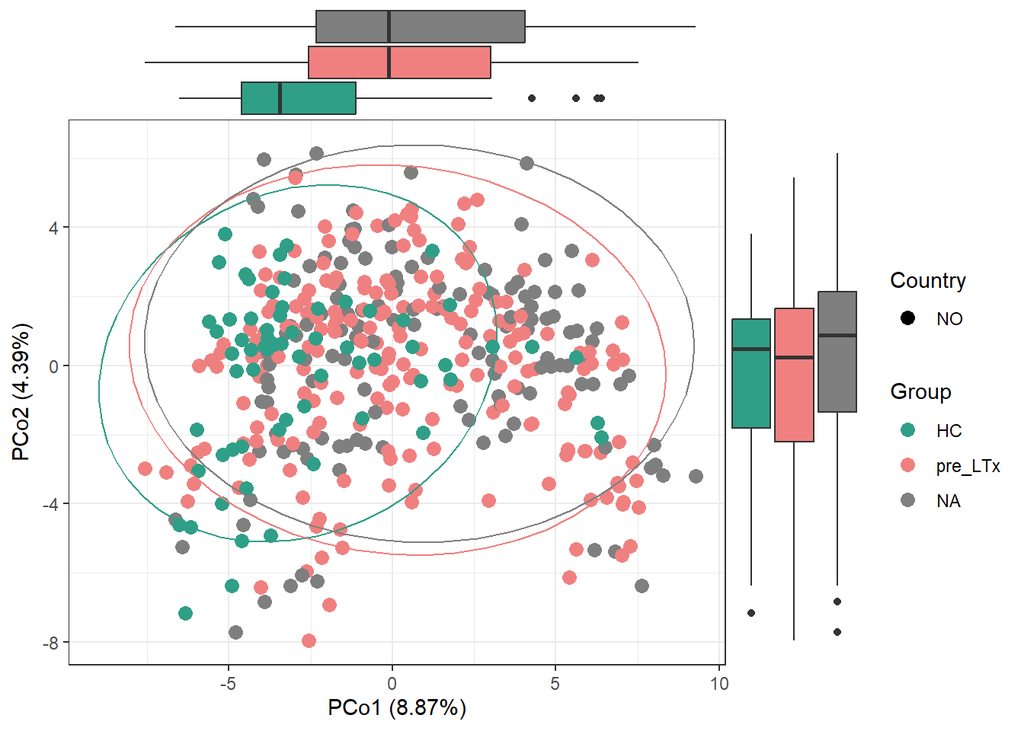

```r
p <- pca_plot_custom(filt_colon_genus_tab,
                                 filt_colon_genus_taxa,
                                 filt_colon_genus_metadata,
                                 show_boxplots = TRUE,
                                 variable = "Group", size=3, show_legend=TRUE)

# save the results
pca_plots_list[[paste(segment,level,"custom")]] <- p

# see the results
p
```

#### Saving results

```r
write.xlsx(pairwise_aitchison_raw[[paste(level, segment)]],
           file = file.path(path,
           paste0("beta_diversity_results_", segment,".xlsx")))
```

### Supplementary analysis

#### Genus level

```r
level="genus"
```

##### Bray-Curtis

**PERMANOVA**

```r
pairwise_df <- filt_colon_genus_tab %>% column_to_rownames("SeqID") %>% t()

# main effect
pp_main <- pairwise.adonis(pairwise_df,filt_colon_genus_metadata$Group,
                           covariate = NULL,
                            patients = filt_colon_genus_metadata$Patient,
                           sim.method = "bray", p.adjust.m="BH")


# tidy the results
pp_factor <- pp_main

cols <- c("pairs","Df","SumsOfSqs", "F.Model","R2","p.value", "p.adjusted", "sig")
colnames(pp_factor) <- cols

# save raw results
supplements_beta[[paste("bray",level,segment)]] <- pp_factor
```

```r
# see the results
knitr::kable(pp_factor,digits = 3,caption = "PERMANOVA, GROUP separation")
```

PERMANOVA, GROUP separation

| pairs | Df | SumsOfSqs | F.Model | R2 | p.value | p.adjusted | sig |
| --- | --- | --- | --- | --- | --- | --- | --- |
| pre_ltx vs healthy | 1 | 2.224 | 10.918 | 0.039 | 0.001 | 0.002 | ** |
| pre_ltx vs post_ltx | 1 | 1.173 | 5.414 | 0.015 | 0.052 | 0.052 |  |
| post_ltx vs healthy | 1 | 2.984 | 14.912 | 0.068 | 0.001 | 0.002 | ** |

**Plots**

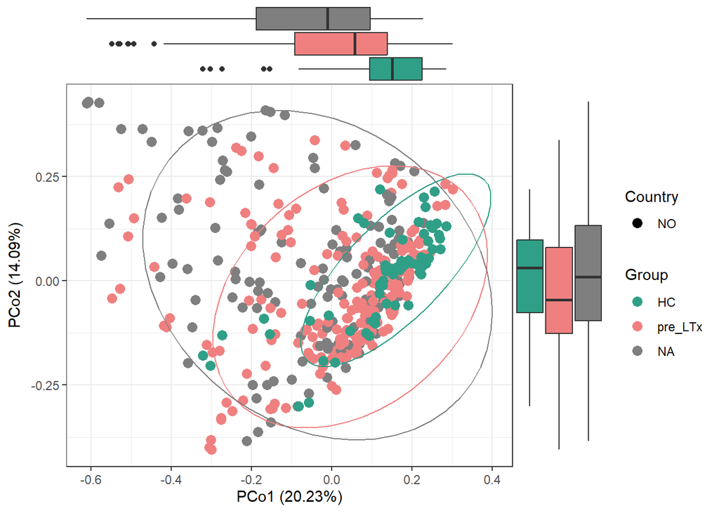

```r
p <- pca_plot_custom(filt_colon_genus_tab,
                                 filt_colon_genus_taxa,
                                 filt_colon_genus_metadata,
                                 measure = "bray",
                                 show_boxplots = TRUE,
                                 variable = "Group", size=3, show_legend=TRUE)

# save the results
supplements_beta[[paste("PCoA bray",level,segment)]] <- p

# see the results
p
```

##### Jaccard

**PERMANOVA**

```r
pairwise_df <- filt_colon_genus_tab %>% column_to_rownames("SeqID") %>% t()

# main effect
pp_main <- pairwise.adonis(pairwise_df,filt_colon_genus_metadata$Group,
                           covariate = NULL,
                            patients = filt_colon_genus_metadata$Patient,
                           sim.method = "jaccard", p.adjust.m="BH")


# tidy the results
pp_factor <- pp_main

cols <- c("pairs","Df","SumsOfSqs", "F.Model","R2","p.value", "p.adjusted", "sig")
colnames(pp_factor) <- cols

# save raw results
supplements_beta[[paste("jaccard",level,segment)]] <- pp_factor
```

```r
# see the results
knitr::kable(pp_factor,digits = 3,caption = "PERMANOVA, GROUP separation")
```

PERMANOVA, GROUP separation

| pairs | Df | SumsOfSqs | F.Model | R2 | p.value | p.adjusted | sig |
| --- | --- | --- | --- | --- | --- | --- | --- |
| pre_ltx vs healthy | 1 | 2.407 | 8.288 | 0.030 | 0.001 | 0.002 | ** |
| pre_ltx vs post_ltx | 1 | 1.254 | 4.150 | 0.012 | 0.078 | 0.078 |  |
| post_ltx vs healthy | 1 | 3.048 | 10.592 | 0.049 | 0.001 | 0.002 | ** |

**Plots**

*Custom*

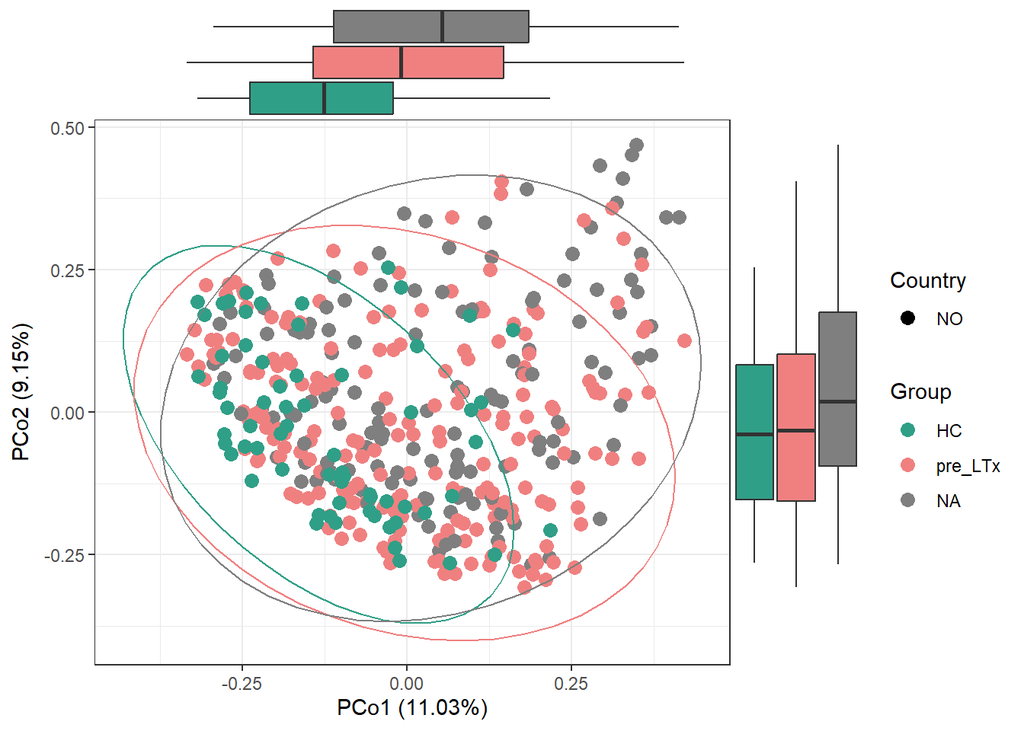

```r
p <- pca_plot_custom(filt_colon_genus_tab,
                                 filt_colon_genus_taxa,
                                 filt_colon_genus_metadata,
                                 measure = "jaccard",
                                 show_boxplots = TRUE,
                                 variable = "Group", size=3, show_legend=TRUE)

# save the results
supplements_beta[[paste("PCoA jaccard",level,segment)]] <- p

# see the results
p
```

#### ASV level

```r
level="ASV"
```

##### Aitchison

*PERMANOVA*

```r
# preparing data frame
pairwise_df <- filt_colon_asv_tab %>% column_to_rownames("SeqID") %>% t()

# main effect
pp_main <- pairwise.adonis(pairwise_df,filt_colon_metadata$Group,
                           covariate = NULL,
                            patients = filt_colon_metadata$Patient,
                           sim.method = "robust.aitchison", p.adjust.m="BH")


# tidy the results
pp_factor <- pp_main

cols <- c("pairs","Df","SumsOfSqs", "F.Model","R2","p.value", "p.adjusted", "sig")
colnames(pp_factor) <- cols

# save raw results
supplements_beta[[paste("aitchison",level,segment)]] <- pp_factor
```

```r
# see the results
knitr::kable(pp_factor,digits = 3,caption = "PERMANOVA, GROUP separation")
```

PERMANOVA, GROUP separation

| pairs | Df | SumsOfSqs | F.Model | R2 | p.value | p.adjusted | sig |
| --- | --- | --- | --- | --- | --- | --- | --- |
| pre_ltx vs healthy | 1 | 2143.719 | 7.928 | 0.028 | 0.001 | 0.002 | ** |
| pre_ltx vs post_ltx | 1 | 936.918 | 3.682 | 0.011 | 0.109 | 0.109 |  |
| post_ltx vs healthy | 1 | 2087.993 | 7.806 | 0.037 | 0.001 | 0.002 | ** |

**PCoA**

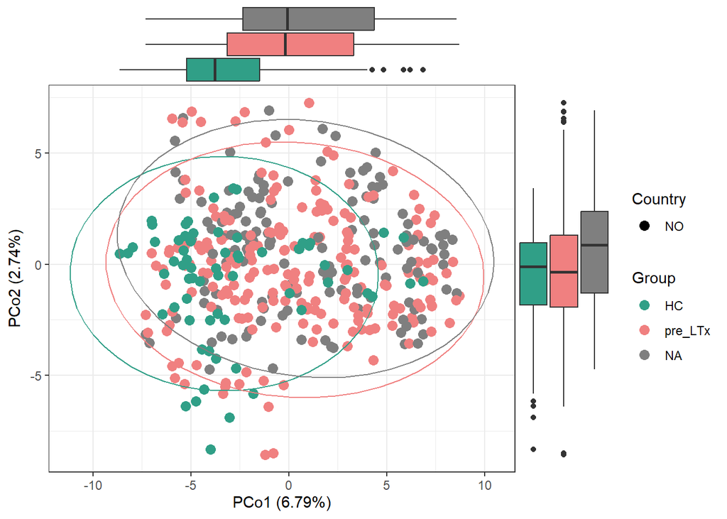

```r
p <- pca_plot_custom(filt_colon_asv_tab,
                           filt_colon_taxa_tab,
                           filt_colon_metadata,
                           show_boxplots = TRUE,
                           variable = "Group", size=3, show_legend=TRUE)

# save the results
supplements_beta[[paste("PCoA aitchison",level,segment)]] <- p

# see the results
p
```

##### Bray-Curtis

*PERMANOVA*

```r
# preparing data frame
pairwise_df <- filt_colon_asv_tab %>% column_to_rownames("SeqID") %>% t()

# main effect
pp_main <- pairwise.adonis(pairwise_df,filt_colon_metadata$Group,
                           covariate = NULL,
                           patients = filt_colon_metadata$Patient,
                           sim.method = "bray", p.adjust.m="BH")


# tidy the results
pp_factor <- pp_main

cols <- c("pairs","Df","SumsOfSqs", "F.Model","R2","p.value", "p.adjusted", "sig")
colnames(pp_factor) <- cols

# save raw results
supplements_beta[[paste("bray",level,segment)]] <- pp_factor
```

```r
# see the results
knitr::kable(pp_factor,digits = 3,caption = "PERMANOVA, GROUP separation")
```

PERMANOVA, GROUP separation

| pairs | Df | SumsOfSqs | F.Model | R2 | p.value | p.adjusted | sig |
| --- | --- | --- | --- | --- | --- | --- | --- |
| pre_ltx vs healthy | 1 | 3.231 | 9.892 | 0.035 | 0.001 | 0.002 | ** |
| pre_ltx vs post_ltx | 1 | 1.822 | 5.456 | 0.015 | 0.010 | 0.010 | ** |
| post_ltx vs healthy | 1 | 4.004 | 12.790 | 0.059 | 0.001 | 0.002 | ** |

**PCoA**

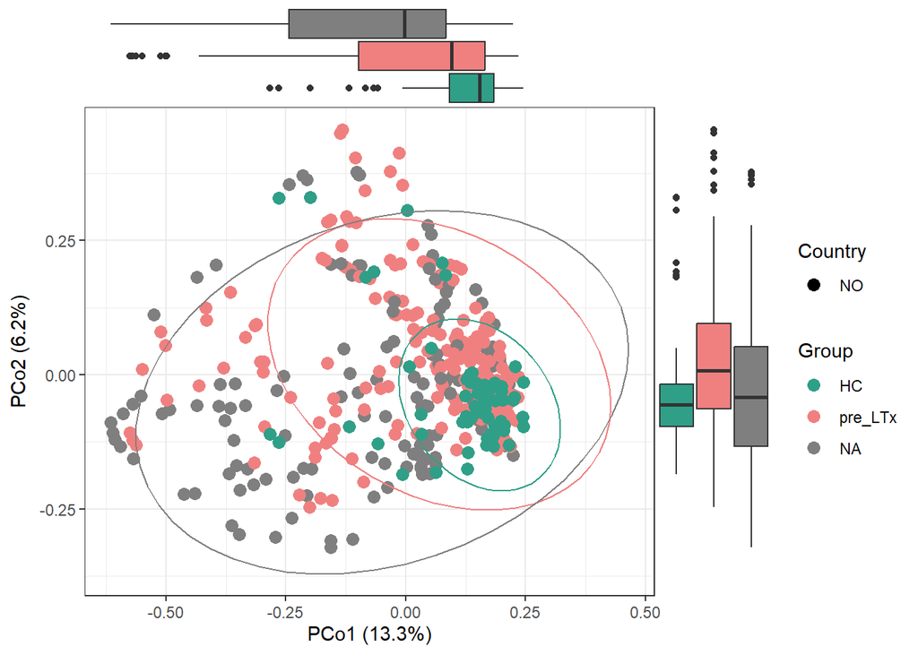

```r
p <- pca_plot_custom(filt_colon_asv_tab,
                     filt_colon_taxa_tab,
                     filt_colon_metadata,
                     measure = "bray",
                     show_boxplots = TRUE,
                     variable = "Group", size=3, show_legend=TRUE)

# save the results
supplements_beta[[paste("PCoA bray",level,segment)]] <- p

# see the results
p
```

##### Jaccard

*PERMANOVA*

```r
# preparing data frame
pairwise_df <- filt_colon_asv_tab %>% column_to_rownames("SeqID") %>% t()

# main effect
pp_main <- pairwise.adonis(pairwise_df,filt_colon_metadata$Group,
                           covariate = NULL,
                           patients = filt_colon_metadata$Patient,
                           sim.method = "jaccard", p.adjust.m="BH")


# tidy the results
pp_factor <- pp_main

cols <- c("pairs","Df","SumsOfSqs", "F.Model","R2","p.value", "p.adjusted", "sig")
colnames(pp_factor) <- cols

# save raw results
supplements_beta[[paste("jaccard",level,segment)]] <- pp_factor
```

```r
# see the results
knitr::kable(pp_factor,digits = 3,caption = "PERMANOVA, GROUP separation")
```

PERMANOVA, GROUP separation

| pairs | Df | SumsOfSqs | F.Model | R2 | p.value | p.adjusted | sig |
| --- | --- | --- | --- | --- | --- | --- | --- |
| pre_ltx vs healthy | 1 | 2.614 | 6.644 | 0.024 | 0.001 | 0.002 | ** |
| pre_ltx vs post_ltx | 1 | 1.649 | 4.143 | 0.012 | 0.031 | 0.031 | * |
| post_ltx vs healthy | 1 | 3.192 | 8.331 | 0.039 | 0.001 | 0.002 | ** |

**PCoA**

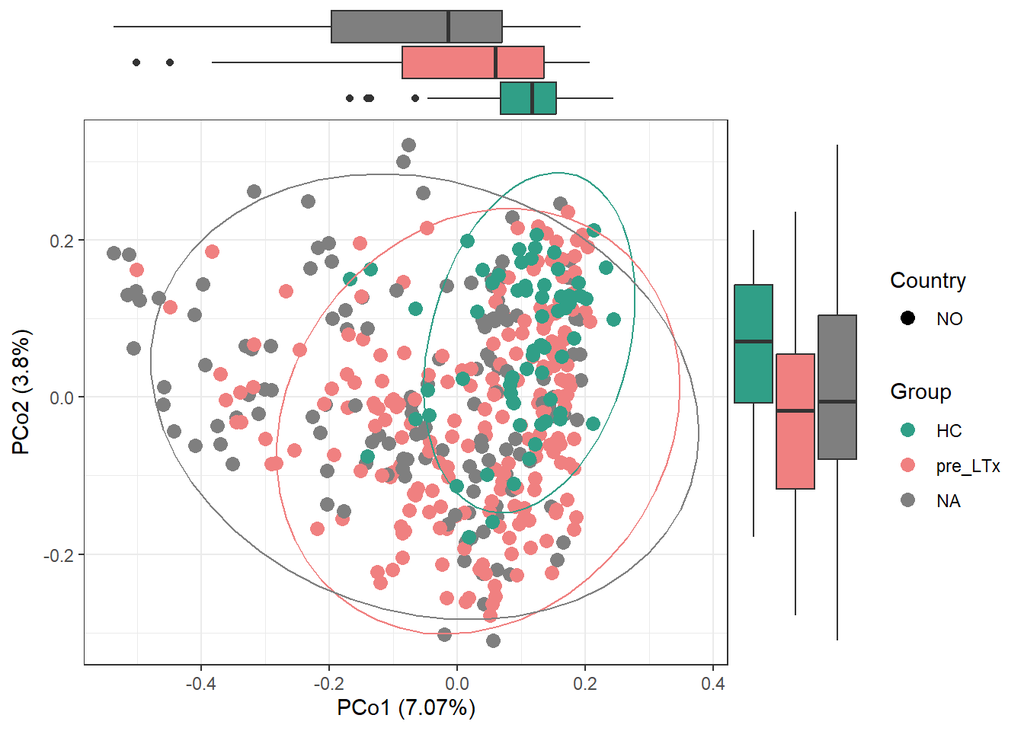

```r
p <- pca_plot_custom(filt_colon_asv_tab,
                     filt_colon_taxa_tab,
                     filt_colon_metadata,
                     measure = "jaccard",
                     show_boxplots = TRUE,
                     variable = "Group", size=3, show_legend=TRUE)

# save the results
supplements_beta[[paste("PCoA jaccard",level,segment)]] <- p

# see the results
p
```

#### Saving results

```r
write.xlsx(supplements_beta[!grepl("PCoA",names(supplements_beta))],
           file = file.path(path,
           paste0("supplements_beta_diversity_", segment,".xlsx")))
```

## Univariate Analysis

### Main - Genus level

```r
level="genus"
```

```r
# needed paths
path = "../results/Q1_norway/univariate_analysis"
path_maaslin=file.path("../intermediate_files/maaslin/Q1_norway/",level)
```

```r
# variables
raw_linda_results_genus[[segment]] <- list()
linda_results_genus[[segment]] <- list()

# country and interaction problems
list_country_union <- list()
list_intersections <- list()
list_venns <- list()
uni_statistics <- list()

# workbook for final df
wb <- createWorkbook()

# PSC effect
psc_effect <- list()
```

#### Genus level

```r
level="genus"
```

Aggregate taxa

```r
genus_data <- aggregate_taxa(colon_asv_tab,
                             colon_taxa_tab,
                             taxonomic_level = level)

colon_genus_tab <- genus_data[[1]]
colon_genus_taxa_tab <- genus_data[[2]]

colon_genus_asv_taxa_tab <- create_asv_taxa_table(colon_genus_tab,
                                                  colon_genus_taxa_tab)
```

##### pre_ltx vs healthy

###### linDA

```r
group <- c("healthy","pre_ltx")
comparison_name <- paste0(group[1], " vs ",group[2])
```

```r
# prepare the data
linda_data <- binomial_prep(colon_genus_tab,
                            colon_genus_taxa_tab,
                            colon_metadata,
                            group, usage="linDA")
```

```
## Removing 54 ASV(s)
```

```
## Removing 11 ASV(s)
```

```r
filt_colon_uni_data <- linda_data[[1]]
filt_colon_uni_taxa <- linda_data[[2]]
filt_colon_uni_metadata <- linda_data[[3]]

# fit the model
linda.obj <- linda(filt_colon_uni_data,
                   filt_colon_uni_metadata,
                   formula = '~ Group + (1|Patient)')
```

```
## 0  features are filtered!
## The filtered data has  274  samples and  167  features will be tested!
## Pseudo-count approach is used.
## Fit linear mixed effects models ...
## Completed.
```

```r
linda.output <- linda.obj$output
linda.output <- linda_renaming(linda.output, group)

# save the results
group1 <- paste0(group[1], " vs ","Group",group[2])


for (grp in c(group1)){
  raw_linda_results_genus[[segment]][[grp]] <-
    rawlinda.df(linda.output,
                grp,
                filt_colon_uni_data,
                filt_colon_uni_taxa)

  linda_results_genus[[segment]][[grp]] <-
    linda.df(linda.output,
             grp,
             filt_colon_uni_data,
             filt_colon_uni_taxa)
}
```

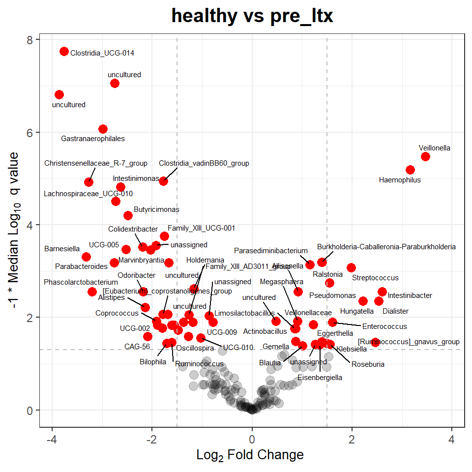

```r
# volcano plot
volcano_1 <- volcano_plot_linda(linda.output, group1,
                                taxa_table = filt_colon_uni_taxa) +
            ggtitle(paste(group,collapse=" vs "))


volcano <- ggarrange(volcano_1)

# see the plot
volcano
```

###### MaAsLin2

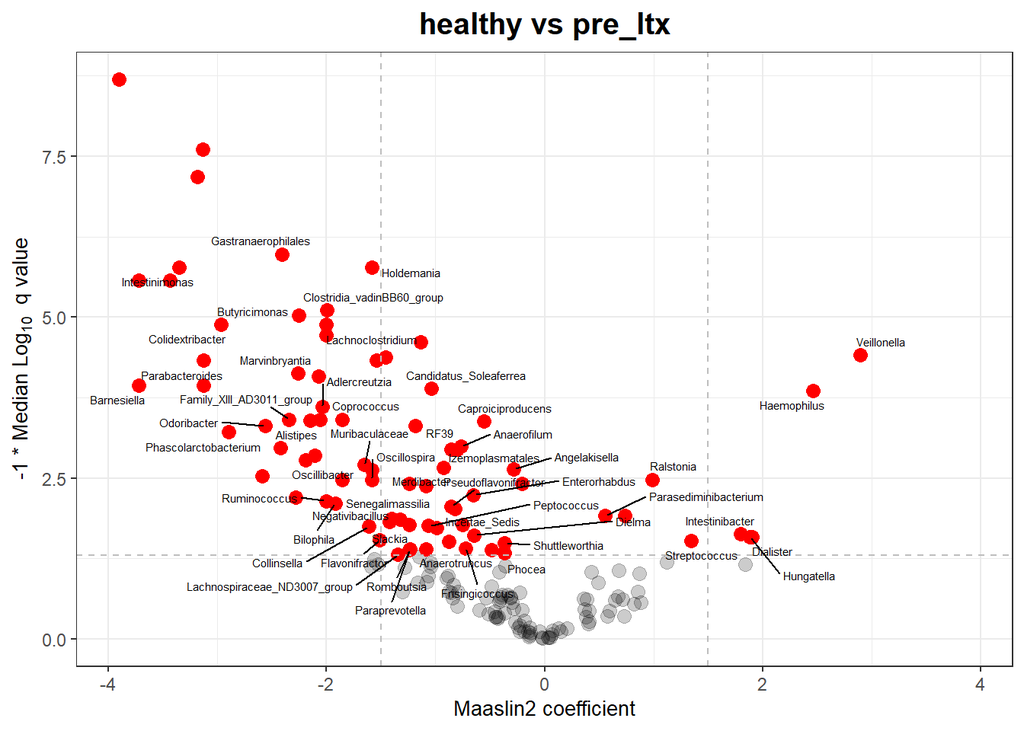

```r
volcano1 <- volcano_plot_maaslin(fit_data,filt_colon_uni_taxa) +
            ggtitle(paste(group[1], "vs", group[2]))


volcano <- ggarrange(volcano1)
volcano
```

###### Group - Intersection

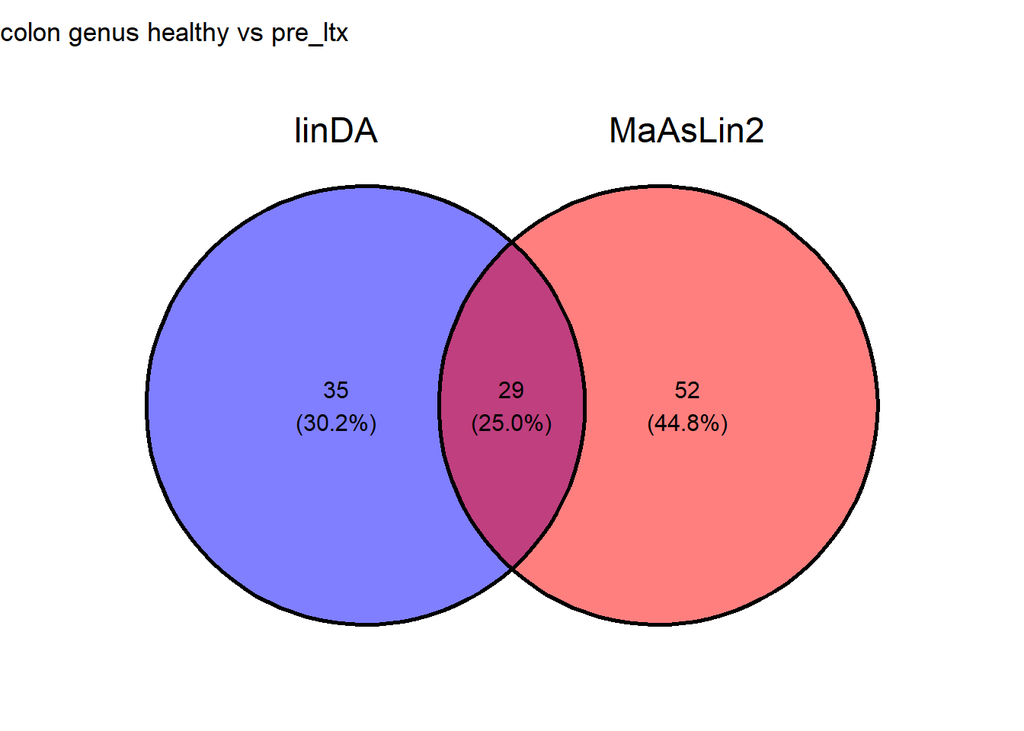

```r
intersection_results <- group_intersection(group, list_intersections, list_venns,
                                           linda.output, fit_data,
                                           raw_linda_results_genus,
                                           segment = segment,
                                           level=level)

list_intersections <- intersection_results[[1]]
list_venns <- intersection_results[[2]]
venn <- intersection_results[[3]]

# show the results
venn
```

###### Basic statistics

```r
uni_df <-  merge(basic_univariate_statistics(linda_data,group),
                 raw_linda_results_genus[[segment]][[group1]],
                 by="SeqID",all=TRUE)
```

```
## [1] "healthy"
## [1] "pre_ltx"
## [1] "healthy"
## [1] "pre_ltx"
```

```r
uni_df[["final_sig"]] <- uni_df$SeqID %in% list_intersections[[paste(segment,level,comparison_name)]][["SeqID"]]
uni_statistics[[segment]][[paste(level,comparison_name)]] <- uni_df

# for comparison
new_name <- comparison_name
addWorksheet(wb, sheetName = new_name)
writeData(wb, sheet = new_name, uni_df, rowNames=FALSE)
```

##### pre_ltx vs post_ltx

```r
group <- c("pre_ltx","post_ltx")
comparison_name <- paste0(group[1], " vs ",group[2])
```

###### linDA

```r
# prepare the data
linda_data <- binomial_prep(colon_genus_tab,
                            colon_genus_taxa_tab,
                            colon_metadata,
                            group, usage="linDA")
```

```
## Removing 18 ASV(s)
```

```
## Removing 13 ASV(s)
```

```r
filt_colon_uni_data <- linda_data[[1]]
filt_colon_uni_taxa <- linda_data[[2]]
filt_colon_uni_metadata <- linda_data[[3]]

# fit the model
linda.obj <- linda(filt_colon_uni_data,
                   filt_colon_uni_metadata,
                   formula = '~ Group + (1|Patient)')
```

```
## 0  features are filtered!
## The filtered data has  349  samples and  140  features will be tested!
## Pseudo-count approach is used.
## Fit linear mixed effects models ...
## Completed.
```

```r
linda.output <- linda.obj$output
linda.output <- linda_renaming(linda.output, group)

# save the results
group1 <- paste0(group[1], " vs ","Group",group[2])


for (grp in c(group1)){
  raw_linda_results_genus[[segment]][[grp]] <-
    rawlinda.df(linda.output,
                grp,
                filt_colon_uni_data,
                filt_colon_uni_taxa)

  linda_results_genus[[segment]][[grp]] <-
    linda.df(linda.output,
             grp,
             filt_colon_uni_data,
             filt_colon_uni_taxa)
}
```

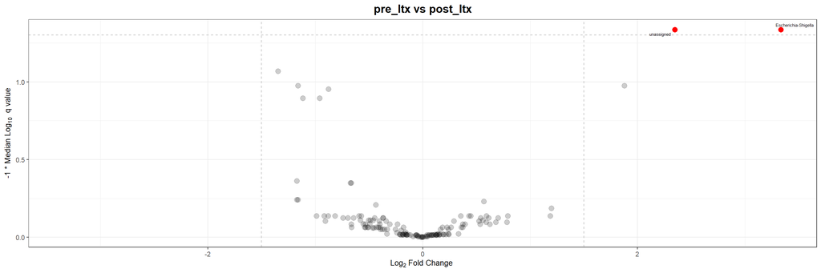

```r
# volcano plot
volcano_1 <- volcano_plot_linda(linda.output, group1,
                                taxa_table = filt_colon_uni_taxa) +
            ggtitle(paste(group,collapse=" vs "))

volcano <- ggarrange(volcano_1)

# see the plot
volcano
```

###### MaAsLin2

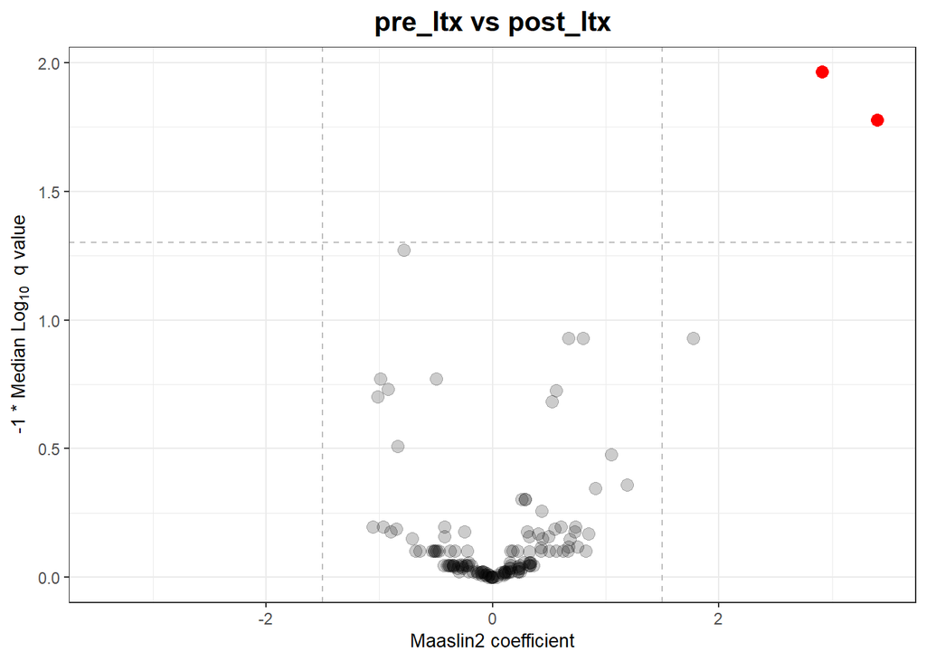

```r
volcano1 <- volcano_plot_maaslin(fit_data,filt_colon_uni_taxa) +
            ggtitle(paste(group[1], "vs", group[2]))


volcano <- ggarrange(volcano1)
volcano
```

###### Group - Intersection

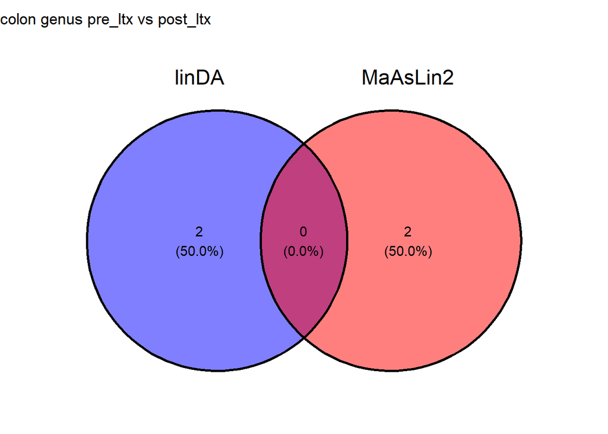

```r
intersection_results <- group_intersection(group,
                                           list_intersections,
                                           list_venns,
                                           linda.output, fit_data,
                                           raw_linda_results_genus,
                                           segment = segment,
                                           level=level)

list_intersections <- intersection_results[[1]]
list_venns <- intersection_results[[2]]
venn <- intersection_results[[3]]

# show the results
venn
```

###### Basic statistics

```r
uni_df <-  merge(basic_univariate_statistics(linda_data,group),
                 raw_linda_results_genus[[segment]][[group1]],
                 by="SeqID",all=TRUE)
```

```
## [1] "pre_ltx"
## [1] "post_ltx"
## [1] "pre_ltx"
## [1] "post_ltx"
```

```r
uni_df[["final_sig"]] <- uni_df$SeqID %in% list_intersections[[paste(segment,level,comparison_name)]][["SeqID"]]
uni_statistics[[segment]][[paste(level,comparison_name)]] <- uni_df

# for comparison
new_name <- comparison_name
addWorksheet(wb, sheetName = new_name)
writeData(wb, sheet = new_name, uni_df, rowNames=FALSE)
```

##### post_ltx vs healthy

```r
group <- c("healthy","post_ltx")
comparison_name <- paste0(group[1], " vs ",group[2])
```

###### linDA

```r
# prepare the data
linda_data <- binomial_prep(colon_genus_tab,
                            colon_genus_taxa_tab,
                            colon_metadata,
                            group, usage="linDA")
```

```
## Removing 97 ASV(s)
```

```
## Removing 7 ASV(s)
```

```r
filt_colon_uni_data <- linda_data[[1]]
filt_colon_uni_taxa <- linda_data[[2]]
filt_colon_uni_metadata <- linda_data[[3]]

# fit the model
linda.obj <- linda(filt_colon_uni_data,
                   filt_colon_uni_metadata,
                   formula = '~ Group + (1|Patient)')
```

```
## 0  features are filtered!
## The filtered data has  207  samples and  164  features will be tested!
## Imputation approach is used.
## Fit linear mixed effects models ...
## Completed.
```

```r
linda.output <- linda.obj$output
linda.output <- linda_renaming(linda.output, group)

# save the results
group1 <- paste0(group[1], " vs ","Group",group[2])


for (grp in c(group1)){
  raw_linda_results_genus[[segment]][[grp]] <-
    rawlinda.df(linda.output,
                grp,
                filt_colon_uni_data,
                filt_colon_uni_taxa)

  linda_results_genus[[segment]][[grp]] <-
    linda.df(linda.output,
             grp,
             filt_colon_uni_data,
             filt_colon_uni_taxa)
}
```

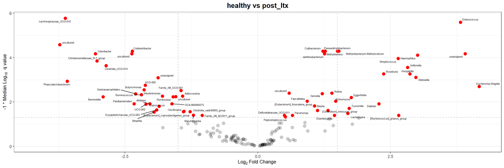

```r
# volcano plot
volcano_1 <- volcano_plot_linda(linda.output, group1,
                                taxa_table = filt_colon_uni_taxa) +
            ggtitle(paste(group,collapse=" vs "))

volcano <- ggarrange(volcano_1)

# see the plot
volcano
```

###### MaAsLin2

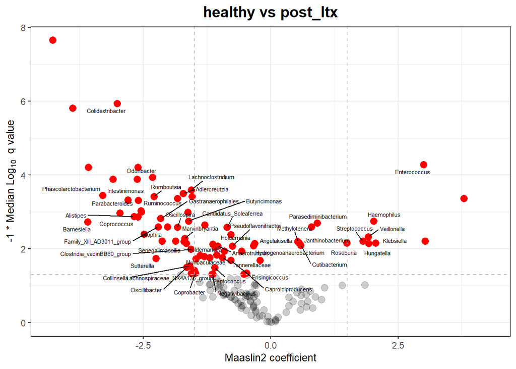

```r
volcano1 <- volcano_plot_maaslin(fit_data,filt_colon_uni_taxa) +
            ggtitle(paste(group[1], "vs", group[2]))

volcano <- ggarrange(volcano1)
volcano
```

###### Group - Intersection

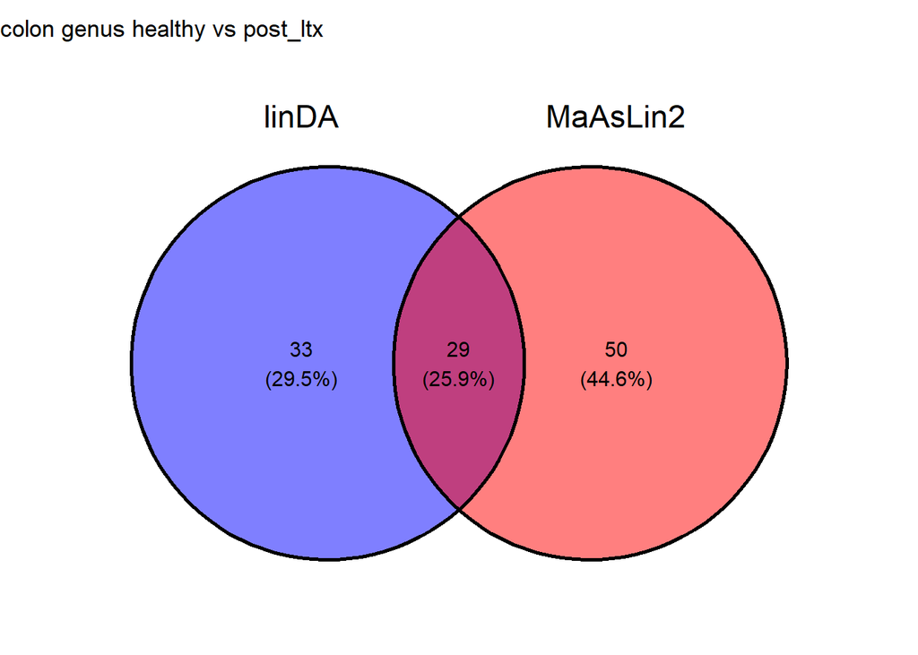

```r
intersection_results <- group_intersection(group, list_intersections, list_venns,
                                           linda.output, fit_data,
                                           raw_linda_results_genus,
                                           segment = segment,
                                           level=level)

list_intersections <- intersection_results[[1]]
list_venns <- intersection_results[[2]]
venn <- intersection_results[[3]]

# show the results
venn
```

###### Basic statistics

```r
uni_df <-  merge(basic_univariate_statistics(linda_data,group),
                 raw_linda_results_genus[[segment]][[group1]],
                 by="SeqID",all=TRUE)
```

```
## [1] "healthy"
## [1] "post_ltx"
## [1] "healthy"
## [1] "post_ltx"
```

```r
uni_df[["final_sig"]] <- uni_df$SeqID %in% list_intersections[[paste(segment,level,comparison_name)]][["SeqID"]]
uni_statistics[[segment]][[paste(level,comparison_name)]] <- uni_df

# for comparison
new_name <- comparison_name
addWorksheet(wb, sheetName = new_name)
writeData(wb, sheet = new_name, uni_df, rowNames=FALSE)
```

##### Visualization

Heatmap visualizing the linDA’s logFoldChange for taxa with p < 0.1.

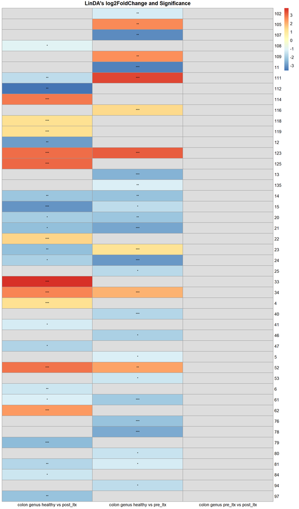

```r
list_heatmap <- list_intersections[grep(paste(segment,level),
                                  names(list_intersections),value=TRUE)]

p_heatmap_linda <- heatmap_linda(list_heatmap,colon_taxa_tab)
p_heatmap_linda
```

Dot heatmap

```r
dotheatmap_linda <- dot_heatmap_linda(list_heatmap,
                                      uni_df,
                                      colon_taxa_tab)
```

```
## min_clr -2.032531
## max_clr 4.8669
## min_log -3.589517
## max_log 3.817599
```

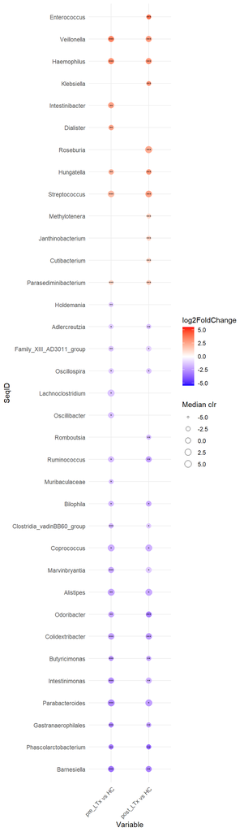

```r
dotheatmap_linda
```

##### PSC effect

**pre_LTx vs Healthy and Post_LTx vs Healthy intersection**

[figure not shown]

```r
A <- list_intersections[[paste(segment,level,"healthy vs pre_ltx")]]$SeqID
B <- list_intersections[[paste(segment,level,"healthy vs post_ltx")]]$SeqID
C <- intersect(A,B)

psc_effect[[paste(segment,level)]] <- list_intersections[[paste(segment,level, "healthy vs pre_ltx")]][list_intersections[[paste(segment,level, "healthy vs pre_ltx")]]$SeqID %in% C,]

# see the results
psc_effect[[paste(segment,level)]]
```

|  | SeqID | Taxonomy | log2FoldChange | p_value | padj |
| --- | --- | --- | --- | --- | --- |
| 5 | Adlercreutzia | k__Bacteria;p__Actinobacteriota;c__Coriobacteriia;o__Coriobacteriales;f__Eggerthellaceae;g__Adlercreutzia | -1.183900 | 3.172236e-03 | 1.268765e-02 |
| 11 | Barnesiella | k__Bacteria;p__Bacteroidota;c__Bacteroidia;o__Bacteroidales;f__Barnesiellaceae;g__Barnesiella | -3.323872 | 4.933922e-05 | 4.846853e-04 |
| 13 | Butyricimonas | k__Bacteria;p__Bacteroidota;c__Bacteroidia;o__Bacteroidales;f__Marinifilaceae;g__Butyricimonas | -2.482190 | 4.172381e-06 | 6.334433e-05 |
| 14 | Odoribacter | k__Bacteria;p__Bacteroidota;c__Bacteroidia;o__Bacteroidales;f__Marinifilaceae;g__Odoribacter | -2.184732 | 4.796011e-04 | 2.761841e-03 |
| 20 | Alistipes | k__Bacteria;p__Bacteroidota;c__Bacteroidia;o__Bacteroidales;f__Rikenellaceae;g__Alistipes | -2.142050 | 1.154529e-03 | 6.025196e-03 |
| 21 | Parabacteroides | k__Bacteria;p__Bacteroidota;c__Bacteroidia;o__Bacteroidales;f__Tannerellaceae;g__Parabacteroides | -2.757943 | 8.298649e-05 | 6.599402e-04 |
| 23 | Parasediminibacterium | k__Bacteria;p__Bacteroidota;c__Bacteroidia;o__Chitinophagales;f__Chitinophagaceae;g__Parasediminibacterium | 1.153334 | 9.446439e-05 | 7.170706e-04 |
| 24 | Gastranaerophilales | k__Bacteria;p__Cyanobacteria;c__Vampirivibrionia;o__Gastranaerophilales;f__Gastranaerophilales;g__Gastranaerophilales | -2.984196 | 2.029384e-08 | 8.472676e-07 |
| 25 | Bilophila | k__Bacteria;p__Desulfobacterota;c__Desulfovibrionia;o__Desulfovibrionales;f__Desulfovibrionaceae;g__Bilophila | -1.707475 | 1.295294e-02 | 3.657455e-02 |
| 34 | Streptococcus | k__Bacteria;p__Firmicutes;c__Bacilli;o__Lactobacillales;f__Streptococcaceae;g__Streptococcus | 1.981020 | 1.161643e-04 | 8.434539e-04 |

[output cut: 12 more lines]

#### Saving results

```r
# ALL DATA
saveWorkbook(wb,file.path(path,paste0("uni_analysis_wb_",segment,".xlsx")),
             overwrite = TRUE)

# PSC effect
write.xlsx(psc_effect[[paste(segment,level)]],file.path(path,paste0("psc_effect_",segment,".xlsx")))

# SIGNIFICANT taxa

write.xlsx(list_intersections[grepl(segment,names(list_intersections))] %>%
            `names<-`(gsub(segment, "", names(
              list_intersections[grepl(segment,names(list_intersections))]))),
           file.path(path,paste0("significant_taxa_",segment,".xlsx")))
```

### Supplementary Analysis

#### ASV level

```r
level="ASV"
```

```r
path_maaslin="../intermediate_files/maaslin/Q1_norway/ASV/"
```

```r
raw_linda_results[[segment]] <- list()
linda_results[[segment]] <- list()
supplements_wb <- createWorkbook()
```

##### pre_ltx vs healthy

```r
group <- c("healthy","pre_ltx")
comparison_name <- paste0(group[1], " vs ",group[2])
```

**linDA**

```r
# prepare the data
linda_data <- binomial_prep(colon_asv_tab,
                            colon_taxa_tab,
                            colon_metadata,
                            group, usage="linDA")
```

```
## Removing 900 ASV(s)
```

```
## Removing 78 ASV(s)
```

```r
filt_colon_uni_data <- linda_data[[1]]
filt_colon_uni_taxa <- linda_data[[2]]
filt_colon_uni_metadata <- linda_data[[3]]

# fit the model
linda.obj <- linda(filt_colon_uni_data,
                   filt_colon_uni_metadata,
                   formula = '~ Group + (1|Patient)',prev.filter = 0.2)
```

```
## 339  features are filtered!
## The filtered data has  273  samples and  174  features will be tested!
## Pseudo-count approach is used.
## Fit linear mixed effects models ...
## Completed.
```

```r
linda.output <- linda.obj$output
linda.output <- linda_renaming(linda.output, group)

group1 <- paste0(group[1], " vs ","Group",group[2])

for (grp in c(group1)){
  raw_linda_results[[segment]][[grp]] <-
    rawlinda.df(linda.output,
                grp,
                filt_colon_uni_data,
                filt_colon_uni_taxa)

  linda_results[[segment]][[grp]] <-
    linda.df(linda.output,
             grp,
             filt_colon_uni_data,
             filt_colon_uni_taxa)
}
```

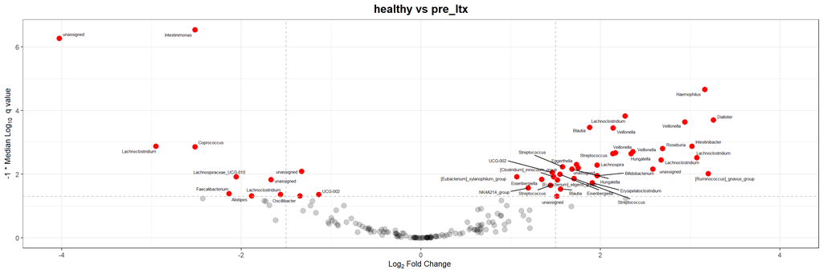

```r
# volcano plot
volcano_1 <- volcano_plot_linda(linda.output, group1,
                                taxa_table = filt_colon_uni_taxa) +
              ggtitle(paste(group,collapse=" vs "))


volcano <- ggarrange(volcano_1)

# see the plot
volcano
```

**MaAsLin2**

Volcano plot

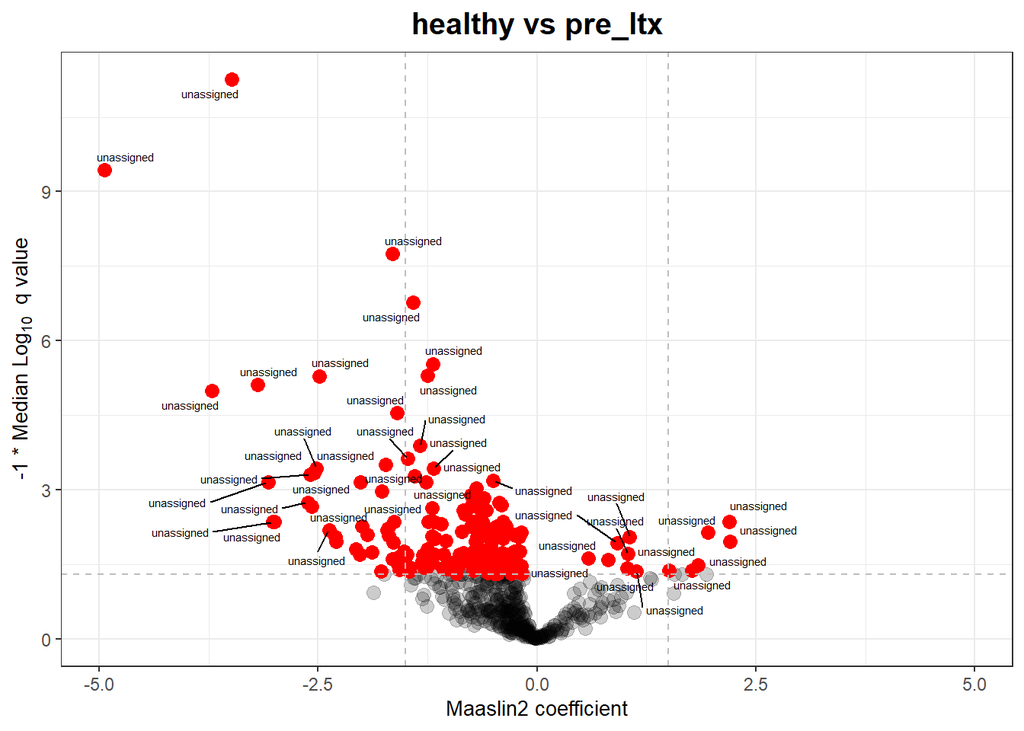

```r
volcano1 <- volcano_plot_maaslin(fit_data,filt_colon_uni_taxa) +
            ggtitle(paste(group[1], "vs", group[2]))

volcano <- ggarrange(volcano1)

# see the results
volcano
```

**Group - Intersection**

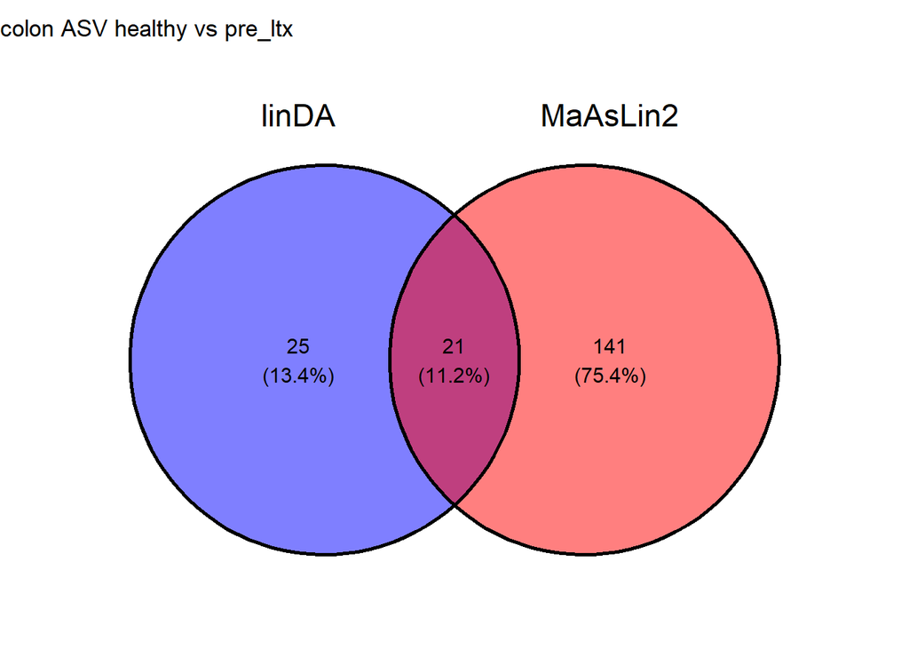

```r
intersection_results <- group_intersection(group, list_intersections, list_venns,
                                           linda.output, fit_data,
                                           raw_linda_results,
                                                                                      segment = segment,
                                           level=level)

list_intersections <- intersection_results[[1]]
list_venns <- intersection_results[[2]]
venn <- intersection_results[[3]]

# show the results
venn
```

**Basic statistics**

```r
uni_df <-  merge(basic_univariate_statistics(linda_data,group),
                 raw_linda_results[[segment]][[group1]],
                 by="SeqID",all=TRUE)
```

```
## [1] "healthy"
## [1] "pre_ltx"
## [1] "healthy"
## [1] "pre_ltx"
```

```r
uni_df[["final_sig"]] <- uni_df$SeqID %in% list_intersections[[paste(segment,level,comparison_name)]][["SeqID"]]
uni_statistics[[segment]][[paste(level,comparison_name)]] <- uni_df

# for comparison
new_name <- paste(level,comparison_name)
addWorksheet(supplements_wb, sheetName = new_name)
writeData(supplements_wb, sheet = new_name, uni_df, rowNames=FALSE)
```

##### pre_ltx vs post_ltx

```r
group <- c("pre_ltx","post_ltx")
comparison_name <- paste0(group[1], " vs ",group[2])
```

**linDA**

```r
# prepare the data
linda_data <- binomial_prep(colon_asv_tab,
                            colon_taxa_tab,
                            colon_metadata,
                            group, usage="linDA")
```

```
## Removing 848 ASV(s)
```

```
## Removing 45 ASV(s)
```

```r
filt_colon_uni_data <- linda_data[[1]]
filt_colon_uni_taxa <- linda_data[[2]]
filt_colon_uni_metadata <- linda_data[[3]]

# fit the model
linda.obj <- linda(filt_colon_uni_data,
                   filt_colon_uni_metadata,
                   formula = '~ Group + (1|Patient)')
```

```
## 0  features are filtered!
## The filtered data has  349  samples and  304  features will be tested!
## Pseudo-count approach is used.
## Fit linear mixed effects models ...
## Completed.
```

```r
linda.output <- linda.obj$output
linda.output <- linda_renaming(linda.output, group)

group1 <- paste0(group[1], " vs ","Group",group[2])

for (grp in c(group1)){
  raw_linda_results[[segment]][[grp]] <-
    rawlinda.df(linda.output,
                grp,
                filt_colon_uni_data,
                filt_colon_uni_taxa)

  linda_results[[segment]][[grp]] <-
    linda.df(linda.output,
             grp,
             filt_colon_uni_data,
             filt_colon_uni_taxa)
}
```

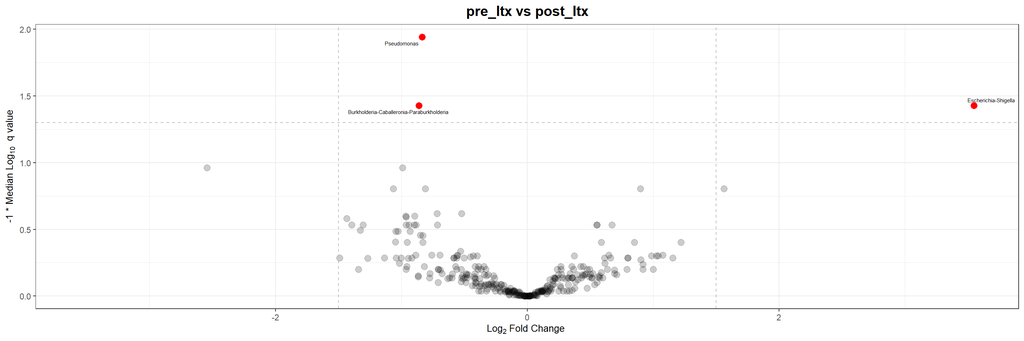

```r
# volcano plot
volcano_1 <- volcano_plot_linda(linda.output, group1,
                                taxa_table = filt_colon_uni_taxa) +
              ggtitle(paste(group,collapse=" vs "))

volcano <- ggarrange(volcano_1)

# see the plot
volcano
```

**MaAsLin2**

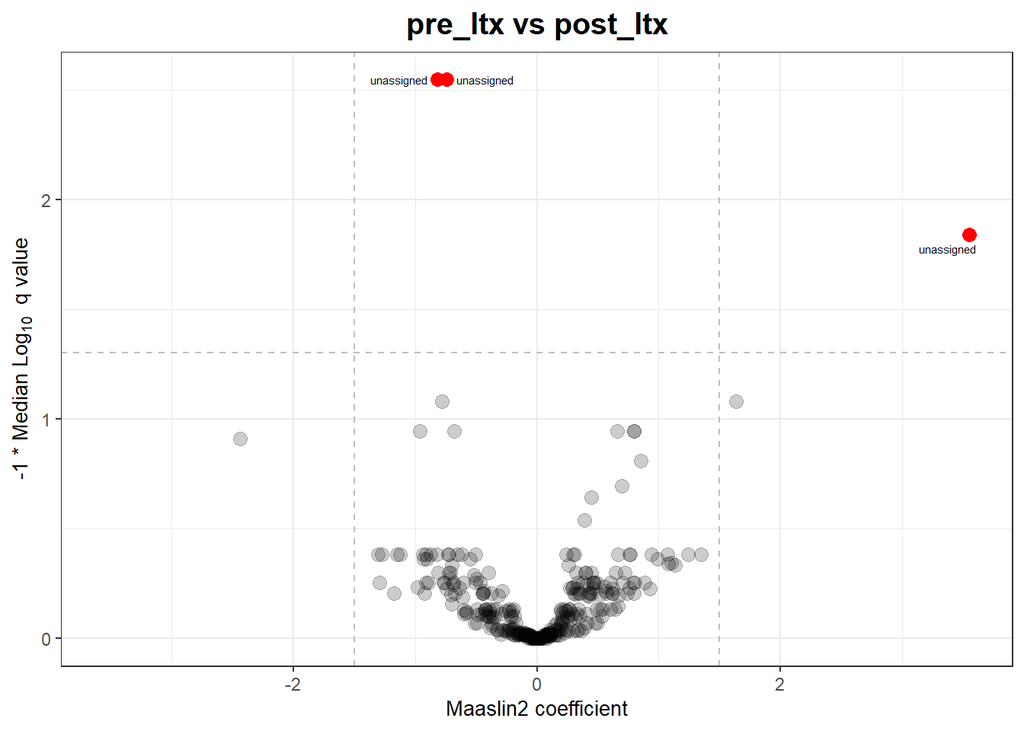

```r
volcano1 <- volcano_plot_maaslin(fit_data,filt_colon_uni_taxa) +
            ggtitle(paste(group[1], "vs", group[2]))

volcano <- ggarrange(volcano1)

# see the results
volcano
```

**Group - Intersection**

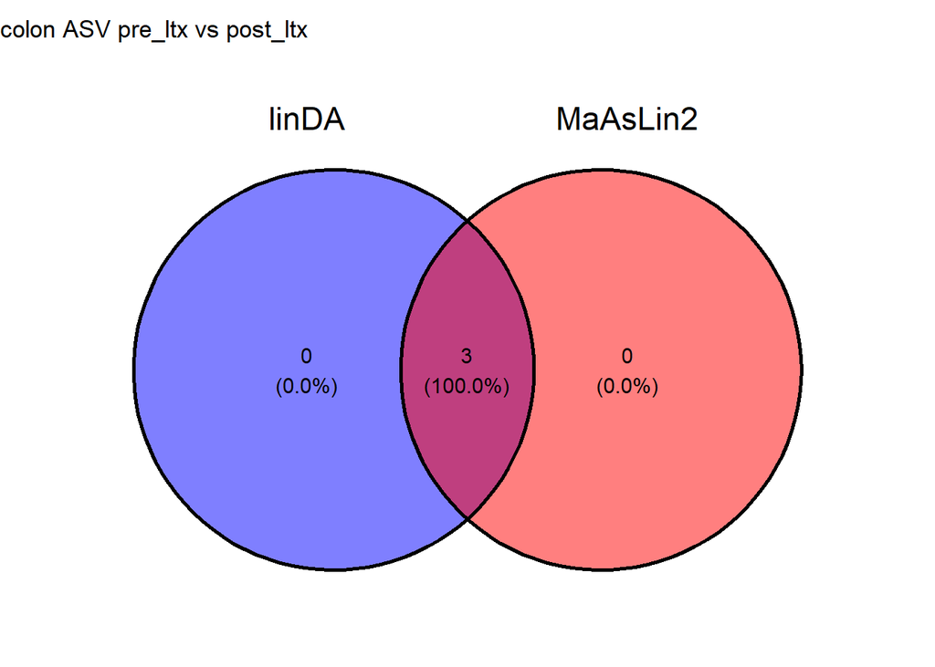

```r
intersection_results <- group_intersection(group, list_intersections, list_venns,
                                           linda.output, fit_data,
                                           raw_linda_results,
                                           segment=segment,
                                           level=level)

list_intersections <- intersection_results[[1]]
list_venns <- intersection_results[[2]]
venn <- intersection_results[[3]]

# show the results
venn
```

**Basic statistics**

```r
uni_df <-  merge(basic_univariate_statistics(linda_data,group),
                 raw_linda_results[[segment]][[group1]],
                 by="SeqID",all=TRUE)
```

```
## [1] "pre_ltx"
## [1] "post_ltx"
## [1] "pre_ltx"
## [1] "post_ltx"
```

```r
uni_df[["final_sig"]] <- uni_df$SeqID %in% list_intersections[[paste(segment,level,comparison_name)]][["SeqID"]]
uni_statistics[[segment]][[paste(level,comparison_name)]] <- uni_df

# for comparison
new_name <- paste(level,comparison_name)
addWorksheet(supplements_wb, sheetName = new_name)
writeData(supplements_wb, sheet = new_name, uni_df, rowNames=FALSE)
```

##### post_ltx vs healthy

```r
group <- c("healthy","post_ltx")
comparison_name <- paste0(group[1], " vs ",group[2])
```

**linDA**

```r
# prepare the data
linda_data <- binomial_prep(colon_asv_tab,
                            colon_taxa_tab,
                            colon_metadata,
                            group, usage="linDA")
```

```
## Removing 1180 ASV(s)
```

```
## Removing 72 ASV(s)
```

```r
filt_colon_uni_data <- linda_data[[1]]
filt_colon_uni_taxa <- linda_data[[2]]
filt_colon_uni_metadata <- linda_data[[3]]

# fit the model
linda.obj <- linda(filt_colon_uni_data,
                   filt_colon_uni_metadata,
                   formula = '~ Group + (1|Patient)')
```

```
## 0  features are filtered!
## The filtered data has  207  samples and  528  features will be tested!
## Imputation approach is used.
## Fit linear mixed effects models ...
## Completed.
```

```r
linda.output <- linda.obj$output
linda.output <- linda_renaming(linda.output, group)

group1 <- paste0(group[1], " vs ","Group",group[2])

for (grp in c(group1)){
  raw_linda_results[[segment]][[grp]] <-
    rawlinda.df(linda.output,
                grp,
                filt_colon_uni_data,
                filt_colon_uni_taxa)

  linda_results[[segment]][[grp]] <-
    linda.df(linda.output,
             grp,
             filt_colon_uni_data,
             filt_colon_uni_taxa)
}
```

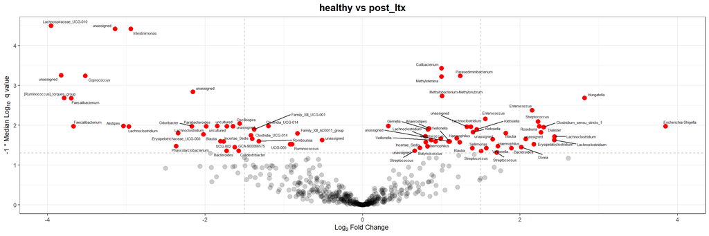

```r
# volcano plot
volcano_1 <- volcano_plot_linda(linda.output, group1,
                                taxa_table = filt_colon_uni_taxa) +
              ggtitle(paste(group,collapse=" vs "))


volcano <- ggarrange(volcano_1)

# see the plot
volcano
```

**MaAsLin2**

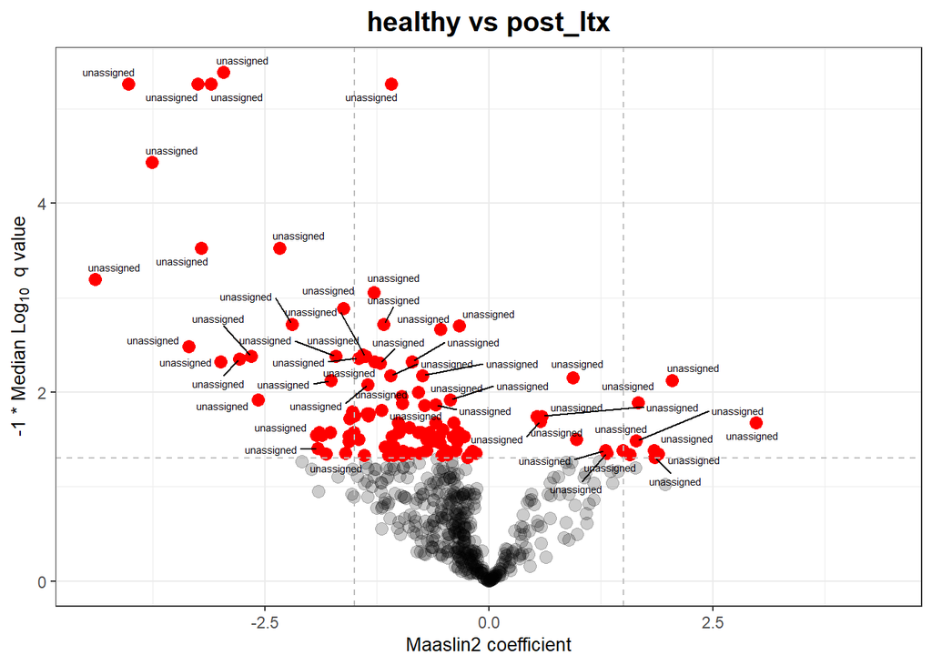

```r
volcano1 <- volcano_plot_maaslin(fit_data,filt_colon_uni_taxa) +
            ggtitle(paste(group[1], "vs", group[2]))

volcano <- ggarrange(volcano1)
volcano
```

**Group - Intersection**

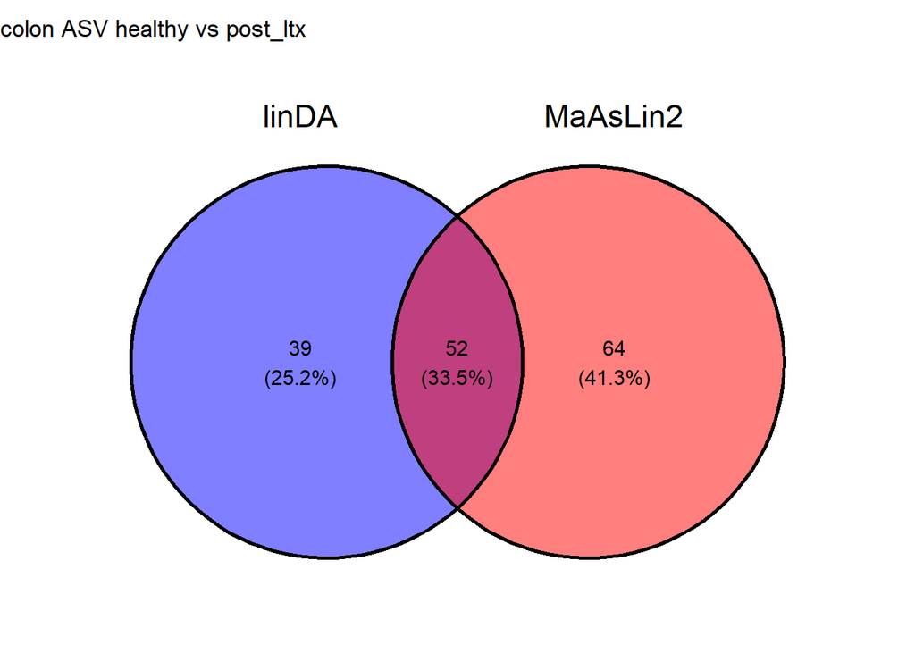

```r
intersection_results <- group_intersection(group, list_intersections, list_venns,
                                           linda.output, fit_data,
                                           raw_linda_results,
                                           segment = segment,
                                           level=level)

list_intersections <- intersection_results[[1]]
list_venns <- intersection_results[[2]]
venn <- intersection_results[[3]]

# show the results
venn
```

**Basic statistics**

```r
uni_df <-  merge(basic_univariate_statistics(linda_data,group),
                 raw_linda_results[[segment]][[group1]],
                 by="SeqID",all=TRUE)
```

```
## [1] "healthy"
## [1] "post_ltx"
## [1] "healthy"
## [1] "post_ltx"
```

```r
uni_df[["final_sig"]] <- uni_df$SeqID %in% list_intersections[[paste(segment,level,comparison_name)]][["SeqID"]]
uni_statistics[[segment]][[paste(level,comparison_name)]] <- uni_df

# for comparison
new_name <- paste(level,comparison_name)
addWorksheet(supplements_wb, sheetName = new_name)
writeData(supplements_wb, sheet = new_name, uni_df, rowNames=FALSE)
```